# Introduction to R

## #Summary statistics

first row, all of the columns

```r
patient_1 <- dat[1, ]
```

max inflammation for patient 1

```r
max(patient_1)
```

```
## [1] 18
```

max inflammation for patient 2

```r
max(dat[2, ])
```

```
## [1] 18
```

minimum inflammation on day 7

```r
min(dat[ , 7])
```

```
## [1] 1
```

mean inflammation on day 7

```r
mean(dat[ , 7])
```

```
## [1] 3.8
```

median inflammation on day 7

```r
median(dat[ , 7])
```

```
## [1] 4
```

standard deviation of inflammation on day 7

```r
sd(dat[ , 7])
```

```
## [1] 1.725187
```

```r
summary(dat[ , 7])
```

```
##    Min. 1st Qu.  Median    Mean 3rd Qu.    Max.
##     1.0     2.0     4.0     3.8     5.0     6.0
```

## #Aggregate across rows or columns

Thus, to obtain the average inflammation of each patient we will need to calculate the mean of all of the rows (`MARGIN = 1`) of the data frame.

```r
avg_patient_inflammation <- apply(dat, 1, mean)
```

And to obtain the average inflammation of each day we will need to calculate the mean of all of the columns (`MARGIN = 2`) of the data frame.

```r
avg_day_inflammation <- apply(dat, 2, mean)
```

standard deviation of day

```r
sd_day_inflammation <- apply(dat, 2, sd)
```

standard deviation of patients

```r
sd_patient_inflammation <- apply(dat, 1, sd)
```

## #Plot data

use the function plot() to plot the data summaries

```r
?plot
```

```
## Help on topic 'plot' was found in the following packages:
##
##   Package               Library
##   graphics              /usr/lib/R/library
##   base                  /usr/lib/R/library
##
##
## Using the first match ...
```

provides a long list of potential arguments and examples at a minimum you must provide a single quantitative variable, for example:

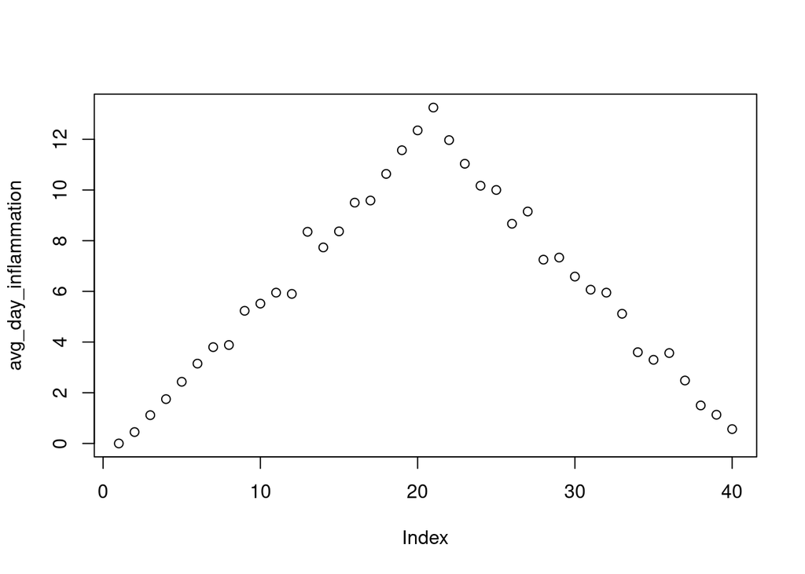

```r
plot(avg_day_inflammation)
```

notice how R fills in lots of pieces of missing information automatically. specifically it assumes that the independent variable is simply an index from 1 to the length of the object in this case avg_day_inflammation. A safer more clear way to accomplish the same plot is to use the following:

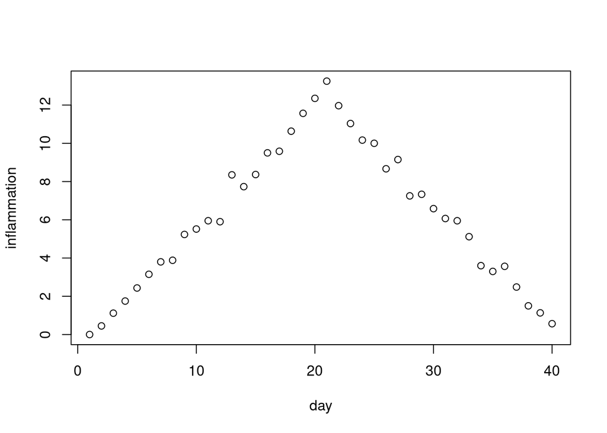

```r
plot(1:length(avg_day_inflammation), avg_day_inflammation, xlab='day',
    ylab='inflammation')
```

this makes it clearer that the x-variable is simply an index from 1 to the length of avg_day_inflammation, and it makes the x and y axis labels more understandable.

Note that in most cases in R you have a specific columns in your `data.frame` you wish to plot against one another. If for example my `data.frame` was called `dat` and there were two columns `growth` and `temperature`. I could plot growth as a function of temperature using `plot(dat$temperature, dat$growth)` This will come up in the homework as well.

To output multi-panel plots use for example

```r
par(mfrow=c(1,2))
```

which will create a single plotting row with two columns

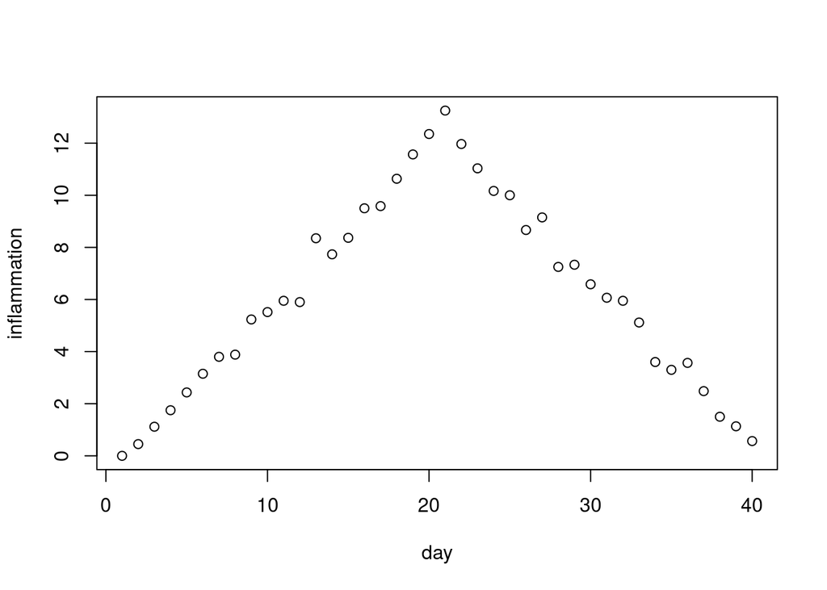

```r
plot(1:length(avg_day_inflammation), avg_day_inflammation, xlab='day',
     ylab='inflammation')
```

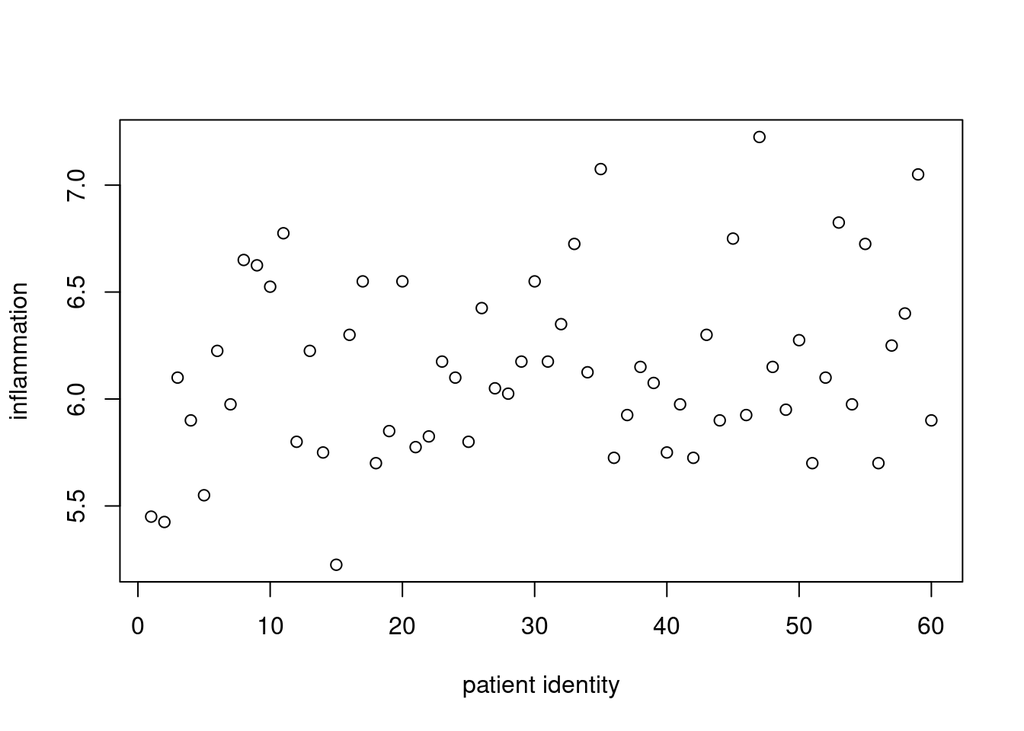

```r
plot(1:length(avg_patient_inflammation), avg_patient_inflammation,
     xlab='patient identity', ylab='inflammation')
```

to output the figure to file you can use Rstudio’s GUI features or you can use the command line which is what I recommend so that the code is fully reproducible:

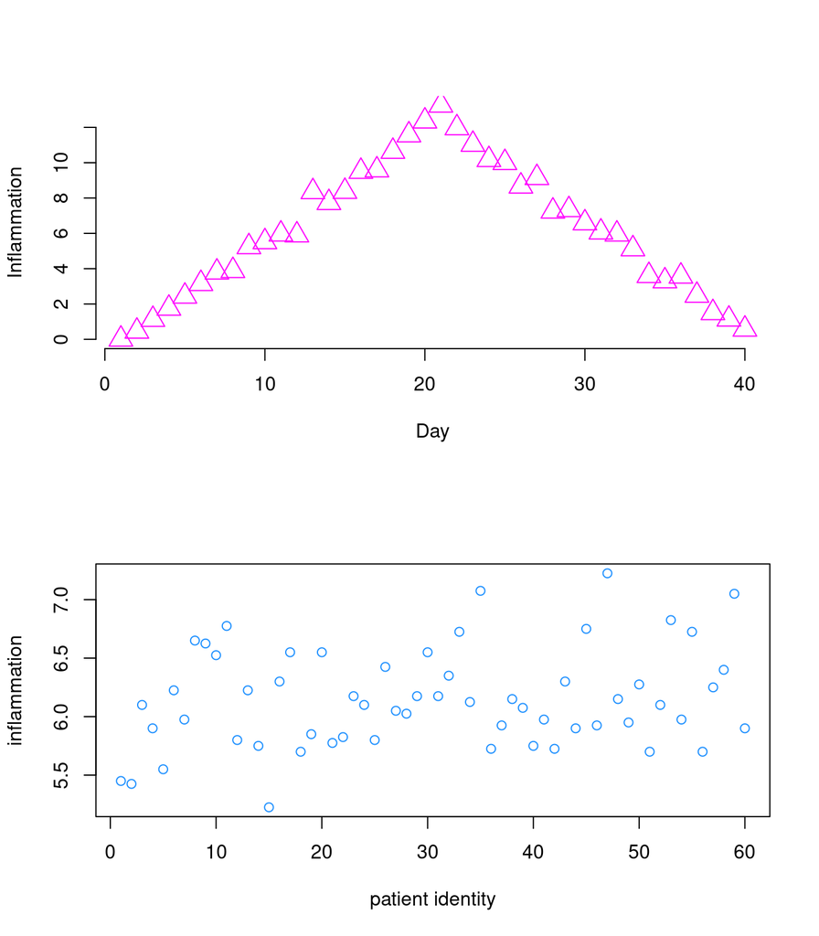

```r
# png('./inflammation_fig1.png') # to create a png file
par(mfrow = c(2,1))
plot(1:length(avg_day_inflammation), avg_day_inflammation, xlab='Day',
     ylab='Inflammation', frame.plot=F, col='magenta', pch=2, cex=2)
plot(1:length(avg_patient_inflammation), avg_patient_inflammation,
     xlab='patient identity', ylab='inflammation', col='dodgerblue')
```

```r
# dev.off()                      # to stop writing to the png file.
```

Home Page - http://dmcglinn.github.io/quant_methods/ GitHub Repo - https://github.com/dmcglinn/quant_methods